# Stats Homework4: IGF

Sophia Frantz

10/30/2019

# How does IGF-1 hormone affect early growth?

# Summary of the data

Data was collected on length (the measure of growth we are interested in) and other factors that may determine length– IGF, sex, age (in weeks), maturity level, and weight (in grams). We are mainly interested in knowing how IGF levels affect length, but we would also like to know whether these other factors determine growth.

I first started by summarizing the variable we wish to predict: length.

```
##    Min. 1st Qu.  Median    Mean 3rd Qu.    Max.
##   111.6   132.9   141.2   141.6   150.2   174.3
```

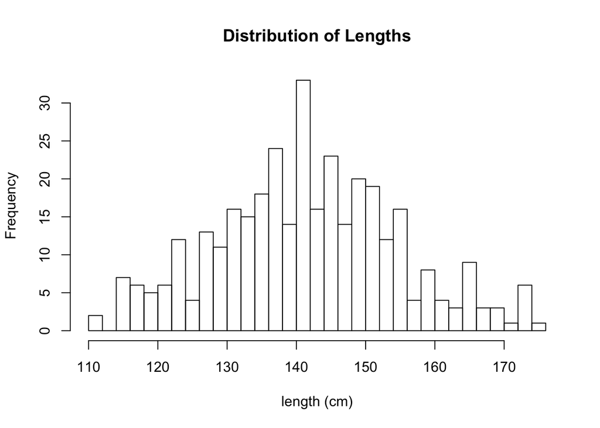

We can see fron this histogram above that the length measurements seem to be normally distributed, with a mean of 141.6 cm and a standard deviation 13.3 cm. There are not many outlier samples. The median and mean are similar, further supporting the conclusion that the data do not have unusual outliers.

This normal distribution makes the interpretation of summary statistics and statistical tests more believable, since many statistical tests assume normality.

I also wanted to look at the factors that may influence length. I wanted to check whether they are also normally distributed and whether they seem to be related to length or to each other.

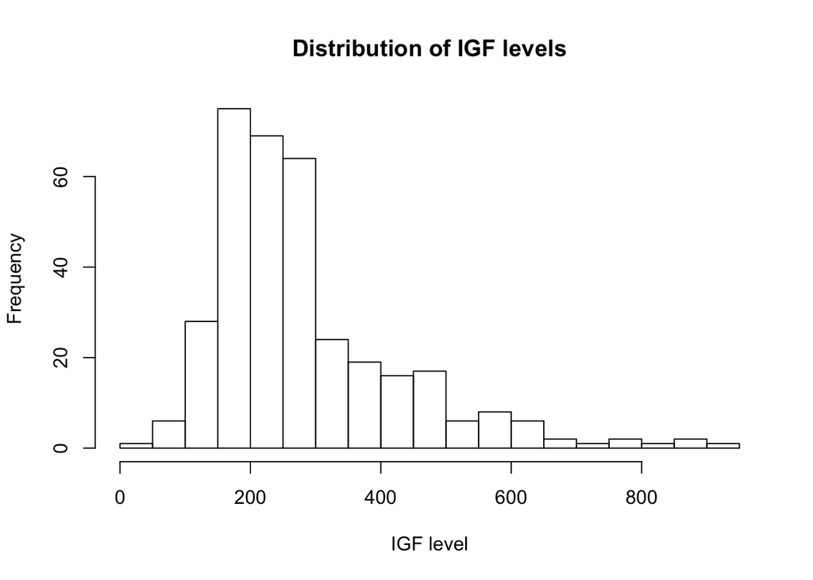

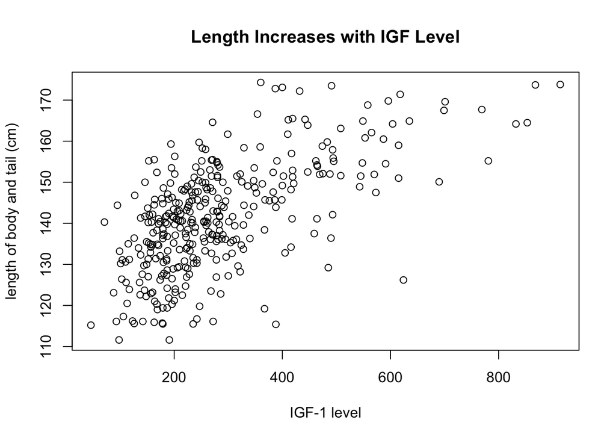

Before constructing the linear model, I first looked at whether length is related to any of the other factors measured:

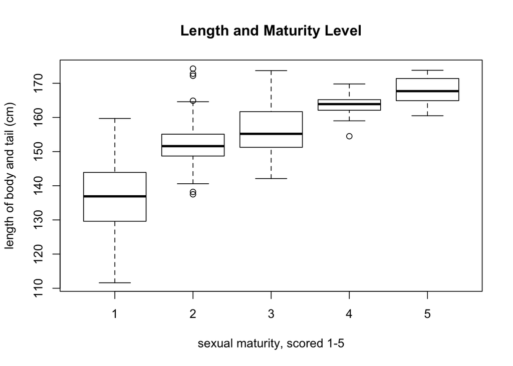

```r
plot(length ~ maturity, data = igf, main = "Length and Maturity Level", ylab = "length of body and tail (cm)", xlab = "sexual maturity, scored 1-5")
```

Above, we see that length increases with maturity level. However, the significance of this trend is not very clear because there is a lot of overlap of variance between groups. Additionally, one level of this factor (maturity level #1) has many more data points, so this comparison is unbalanced. It is unclear whether more data points for the other levels may give us different trends. It will be interesting to see whether maturity level adds significantly to the model.

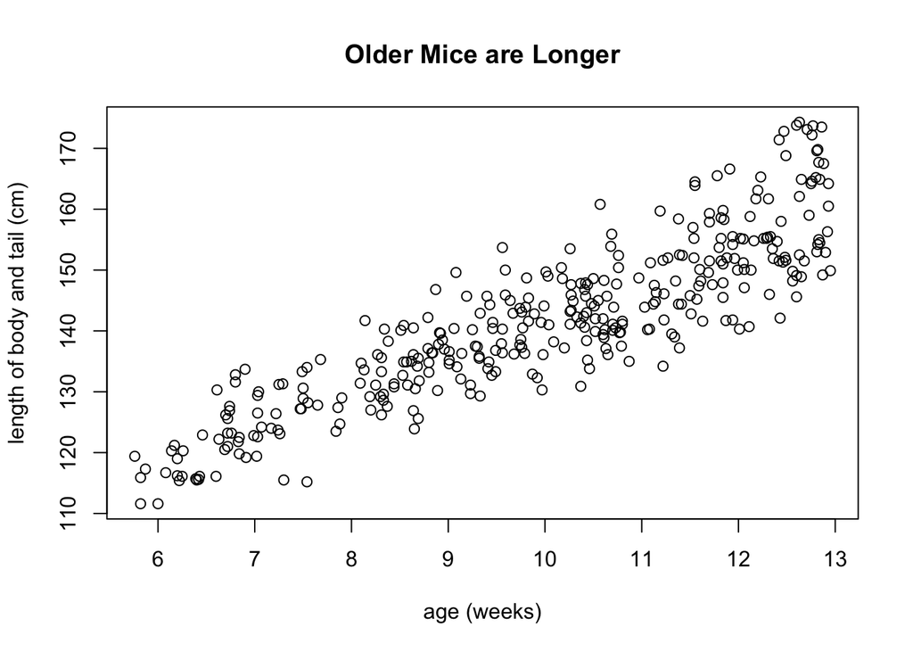

```r
plot(length ~ age, data = igf, main = "Older Mice are Longer", ylab = "length of body and tail (cm)", xlab = "age (weeks)")
```

The trend between age and length is much more clear: length increases with age linearly. I think age will contribute significantly to predicting length in the linear model.

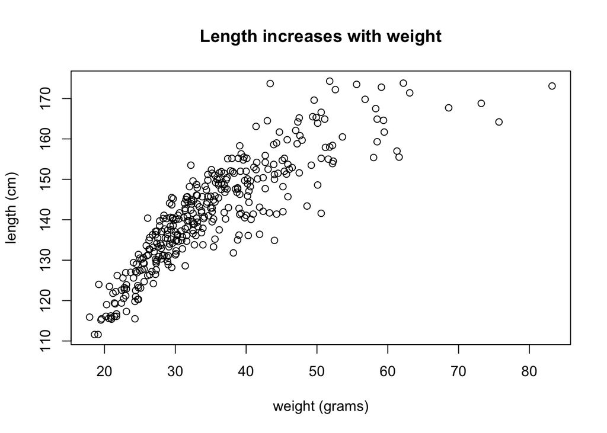

```r
plot(length ~ weight, data = igf, xlab = "weight (grams)", ylab = "length (cm)", main = "Length increases with weight")
```

Length also increases with weight, until at about 50 grams mice stop growing in length but continue to add weight. I think weight will also contribute significantly to predicting length in the linear model.

# Effects of Sex

I was curious to see whether length would be different between males and females. I predicted male mice would be longer. However, I found that length does not differ between the sexes. They have almost the same mean (142.2 cm females and 141.0 cm males), as shown in the boxplot below. Interestingly, IGF level does differ between the sexes, as can be seen in the boxplot and from the results of the t-test which rejects the null hypothesis that the difference between means is 0. I wonder, if IGF level predicts length in the model, whether sex will contribute to the prediction of length because of its relationship to IGF levels?

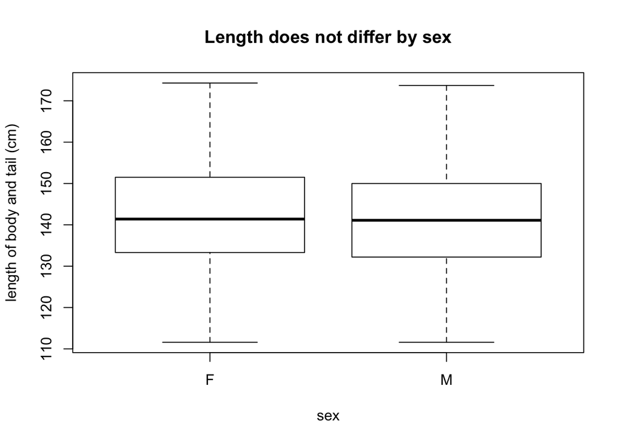

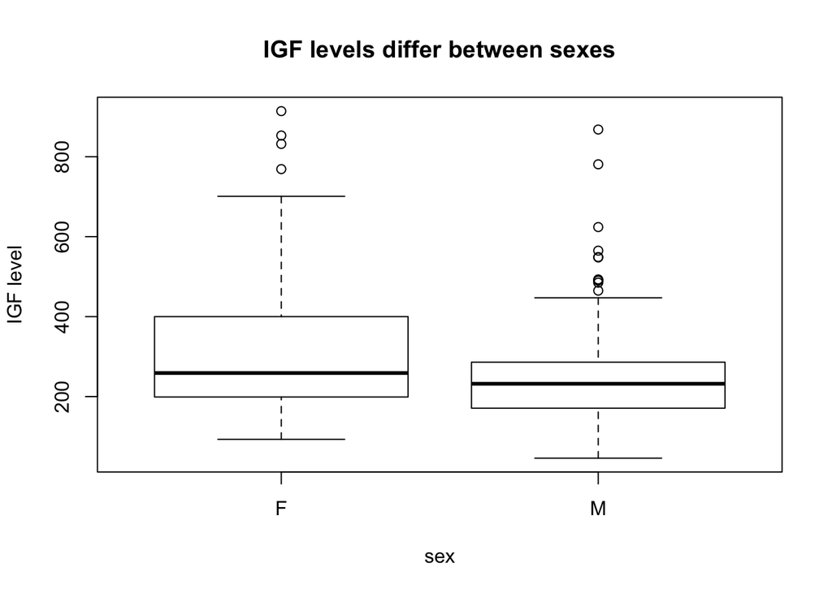

```
##
##  Welch Two Sample t-test
##
## data:  igf$igf[igf$sex == "F"] and igf$igf[igf$sex == "M"]
## t = 4.2358, df = 317.61, p-value = 2.987e-05
## alternative hypothesis: true difference in means is not equal to 0
## 95 percent confidence interval:
##  34.67474 94.82657
## sample estimates:
## mean of x mean of y
##  316.6821  251.9314
```

# The effects of IGF and other factors on the linear model for predicting length

## Additive effects

I first looked at how each factor contributes to the model in an additive manner. I found that IGF, weight, and age contribute to the predictive power of the model. Sex does not contribute significantly to the model. Maturity contributes to the model when it is added before age, but when it is added to the model after age it no longer significantly contributes. I think this is because age is absorbing the effects of maturity level. However, the reverse is not true–age contributes to the model both when it is added before and after maturity level. This means age is a better predictor of length than maturity level, which makes sense given the plots above in which it is easier to see a relationship between age and length than between maturity level and length.

On a similar note, I have shown the results for IGF predicting length as the one of the first factors tested, but IGF significantly contributes to the model when it is added after all the other factors too.

| Model | Effect of adding | df | F | p-value |
| --- | --- | --- | --- | --- |
| length ~ weight |  |  |  |  |
| length ~ weight + igf | igf | 1 | 78.1 | 2.2e-16 *** |
| length ~ weight + igf + maturity | maturity | 4 | 11.1 | 1.926e-08 *** |
| length ~ weight + igf + maturity + age | age | 1 | 307.8 | 2.2e-16 *** |
| length ~ weight + igf + maturity + age + sex | sex | 1 | 0.33 | 0.5641 |
| length ~ weight + igf + age + maturity | maturity (after age) | 4 | 1.39 | 0.24 |
| length ~ weight + maturity + age + sex + igf | igf (last) | 2 | 6.1 | 0.0024** |

## Interactive effects

I next checked for interactive effects. I did not look at the effect of sex or maturity level in this model because I determined they did not have a significant enough effect in the additive model above. I found that the interactive effect of igf and weight was significant (F = 63.683, p= 2.216e-14 ***). However, when I looked at the coefficients for this interaction effect (more on coefficients below), I found that the coefficient was significant but had a very small and negative effect. Given this small effect and the fact that I cannot think of an obvious biological reason that weight and IGF levels should interact non-additively, I decided to only use the additive effects in my final model.

# Estimates of the coefficients

I decided to use IGF level, weight, and age in my final model. These factors both contribute significantly to the model and have an interpretable biological connection to growth.

| coefficients | Estimate | Std. Error | t value | Pr(>\|t\|) |
| --- | --- | --- | --- | --- |
| (Intercept) | 85.398131 | 1.243374 | 68.683 | < 2e-16 *** |
| igf | 0.009932 | 0.002021 | 4.914 | 1.38e-06 *** |
| weight | 0.559401 | 0.035897 | 15.584 | < 2e-16 *** |
| age | 3.387156 | 0.182197 | 18.591 | < 2e-16 *** |

In conclusion, the length of the mice is best predicted by IGF level, weight, and age.